# Table of Contents

```python
import pandas as pd
import numpy as np
import cartopy.crs as ccrs
from cartopy.mpl.ticker import LongitudeFormatter, LatitudeFormatter
import matplotlib.pyplot as plt
from scipy import stats
```

# 1. Significant earthquakes since 2150 B.C.

## Total deaths

Compute the total number of deaths caused by earthquakes since 2150 B.C. in each country, and then print the top ten countries along with the total number of deaths.

```python
# Read .tsv data using pd.read_csv
# Setting sep='\t'
ds = pd.read_csv('Data/PS2/earthquakes-2021-10-13_19-04-37_+0800.tsv',sep='\t',encoding='utf-8',)
```

```python
ds.head()
```

|  | Search Parameters | Year | Mo | Dy | Hr | Mn | Sec | Tsu | Vol | Country | ... | Total Missing | Total Missing Description | Total Injuries | Total Injuries Description | Total Damage ($Mil) | Total Damage Description | Total Houses Destroyed | Total Houses Destroyed Description | Total Houses Damaged | Total Houses Damaged Description |
| --- | --- | --- | --- | --- | --- | --- | --- | --- | --- | --- | --- | --- | --- | --- | --- | --- | --- | --- | --- | --- | --- |
| 0 | [] | NaN | NaN | NaN | NaN | NaN | NaN | NaN | NaN | NaN | ... | NaN | NaN | NaN | NaN | NaN | NaN | NaN | NaN | NaN | NaN |
| 1 | NaN | -2150.0 | NaN | NaN | NaN | NaN | 0.0 | NaN | NaN | JORDAN | ... | NaN | NaN | NaN | NaN | NaN | NaN | NaN | NaN | NaN | NaN |
| 2 | NaN | -2000.0 | NaN | NaN | NaN | NaN | NaN | 1.0 | NaN | SYRIA | ... | NaN | NaN | NaN | NaN | NaN | NaN | NaN | NaN | NaN | NaN |
| 3 | NaN | -2000.0 | NaN | NaN | NaN | NaN | NaN | NaN | NaN | TURKMENISTAN | ... | NaN | NaN | NaN | NaN | NaN | 1.0 | NaN | 1.0 | NaN | NaN |
| 4 | NaN | -1610.0 | NaN | NaN | NaN | NaN | NaN | 3.0 | 1351.0 | GREECE | ... | NaN | NaN | NaN | NaN | NaN | 3.0 | NaN | NaN | NaN | NaN |

5 rows × 48 columns

```python
country_group = ds.groupby(by='Country').sum()
country_group.sort_values(by='Deaths',na_position='last',ascending=False)['Deaths']
```

```
Country
CHINA                               2074900.0
TURKEY                              1074769.0
IRAN                                1011437.0
SYRIA                                439224.0
ITALY                                434863.0
                                      ...
PALAU                                     0.0
SAINT VINCENT AND THE GRENADINES          0.0
SAMOA                                     0.0
SAUDI ARABIA                              0.0
ZAMBIA                                    0.0
Name: Deaths, Length: 156, dtype: float64
```

## Total earthquakes (m>6)

Compute the total number of earthquakes with magnitude larger than 6.0 (use column Mag as the magnitude) worldwide each year, and then plot the time series. Do you observe any trend? Explain why or why not?

```python
Earthquake_Year=pd.DataFrame({'Year':ds[ds.Mag>6].Year,'Count':np.ones(len(ds[ds.Mag>6]))})
Earthquake_Year.head()
```

|  | Year | Count |
| --- | --- | --- |
| 1 | -2150.0 | 1.0 |
| 3 | -2000.0 | 1.0 |
| 8 | -1250.0 | 1.0 |
| 9 | -1050.0 | 1.0 |
| 15 | -479.0 | 1.0 |

```python
Earthquakes_group = Earthquake_Year.groupby(by='Year').sum()
Earthquakes_group
```

| Year | Count |
| --- | --- |
| -2150.0 | 1.0 |
| -2000.0 | 1.0 |
| -1250.0 | 1.0 |
| -1050.0 | 1.0 |
| -479.0 | 1.0 |
| ... | ... |
| 2017.0 | 32.0 |
| 2018.0 | 27.0 |
| 2019.0 | 27.0 |
| 2020.0 | 15.0 |
| 2021.0 | 17.0 |

530 rows × 1 columns

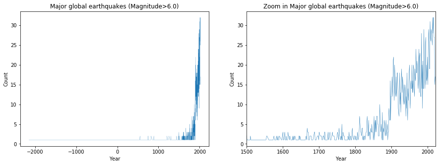

```python
fig,ax = plt.subplots(1,2,figsize=(15,5))
ax[0].plot(Earthquakes_group,lw=0.25)
ax[0].set_title('Major global earthquakes (Magnitude>6.0)')
ax[1].plot(Earthquakes_group,lw=0.5)
ax[1].set_xlim(1500,2022)
ax[1].set_title('Zoom in Major global earthquakes (Magnitude>6.0)')
for a in ax:
    a.set_xlabel('Year')
    a.set_ylabel('Count')
```

There is a clear increasing trend in global major earthquakes (magnitude > 6.0). One main reason is the earthquake records are more in the recent days. The historical data is often deficient in available records.

## CountEq_LargestEq

Write a function CountEq_LargestEq that returns both (1) the total number of earthquakes since 2150 B.C. in a given country AND (2) the date of the largest earthquake ever happened in this country. Apply CountEq_LargestEq to every country in the file, report your results in a descending order.

### Give a country's name then return the largest eathquake occurrence time total earthquakes

```python
def CountEq_LargestEq():
    country=input('Country Name (capitalize): ')
    data=pd.DataFrame({'Year':ds.Year,
              'Mo':ds.Mo,
              'Dy':ds.Dy,
              'Hr':ds.Hr,
              'Mn':ds.Mn,
              'Sec':ds.Sec,
              'Mag':ds.Mag,
              'Country':ds.Country,
              'Count':np.ones(len(ds))})
    data_max = data.groupby(by='Country').max()
    data_count = data.groupby(by='Country').sum()['Count']

    Eq_max_date= 'Largest Earthquake Occurrence Date: %4d-'%data_max.loc[country][0]+'%2d-'%data_max.loc[country][1]+'%2d '%data_max.loc[country][2]+'%2d:'%data_max.loc[country][3]+'%2d:'%data_max.loc[country][4]+'%2d'%data_max.loc[country][5]
    Eq_tot_count='Total number of earthquakes since 2150 B.C.: %s'%data_count.loc[country]
    return Eq_max_date,Eq_tot_count
```

```python
CountEq_LargestEq()
```

```
Country Name (capitalize): CHINA
```

```
('Largest Earthquake Occurrence Date: 2021-12-31 23:59:59',
 'Total number of earthquakes since 2150 B.C.: 610.0')
```

### Apply CountEq_LargestEq to every country

```python
def CountEq_LargestEq():
    #country=input('Country Name (capitalize): ')
    data=pd.DataFrame({'Year':ds.Year,
              'Mo':ds.Mo,
              'Dy':ds.Dy,
              'Hr':ds.Hr,
              'Mn':ds.Mn,
              'Sec':ds.Sec,
              'Mag':ds.Mag,
              'Country':ds.Country,
              'Count':np.ones(len(ds))})
    global data_max
    data_max = data.groupby(by='Country').max()
    global data_count
    data_count = data.groupby(by='Country').sum()['Count']
    ds_out=pd.merge(data_max.iloc[:,0:4],pd.DataFrame({'sum':data_count}),right_index=True,left_index=True)
    return ds_out
```

```python
All_country=CountEq_LargestEq()
```

```python
All_country.sort_values(by='Year',na_position='last',ascending=False)
```

| Country | Year | Mo | Dy | Hr | sum |
| --- | --- | --- | --- | --- | --- |
| HAITI | 2021.0 | 12.0 | 29.0 | 21.0 | 17.0 |
| PAKISTAN | 2021.0 | 12.0 | 30.0 | 23.0 | 53.0 |
| PERU | 2021.0 | 12.0 | 31.0 | 23.0 | 185.0 |
| PHILIPPINES | 2021.0 | 12.0 | 31.0 | 23.0 | 221.0 |
| CHINA | 2021.0 | 12.0 | 31.0 | 23.0 | 610.0 |
| ... | ... | ... | ... | ... | ... |
| NORWAY | 1819.0 | 8.0 | 31.0 | NaN | 1.0 |
| CANARY ISLANDS | 1810.0 | 3.0 | 20.0 | NaN | 2.0 |
| SIERRA LEONE | 1795.0 | 5.0 | 20.0 | 22.0 | 1.0 |
| NORTH KOREA | 1727.0 | 8.0 | 31.0 | NaN | 6.0 |
| IRELAND | 1490.0 | NaN | NaN | NaN | 1.0 |

156 rows × 5 columns

## A failed attempt: pd.to_datetime error

**For example,**

```python
All_country.iloc[0,:3]
```

```
Year    2018.0
Mo        12.0
Dy        31.0
Name: AFGHANISTAN, dtype: float64
```

```python
dt=''
for dt_i in All_country.iloc[0,:3]:
    dt+=str(int(dt_i))
```

```python
pd.to_datetime(dt)
```

```
Timestamp('2018-12-31 00:00:00')
```

**Changing time to datetime usually simplifies the data analysis**

**But the method pd.to_datetime cannot be used for the entire data**

```python
dtime=[]
for i in range(len(data_max)):
    dt=''
    dt_i = data_max.iloc[i,:3].ravel()
    if (np.isnan(dt_i).any()==True):
        if (np.argwhere(np.isnan(dt_i))==0):
            dt=np.nan
        if (np.argwhere(np.isnan(dt_i))==1):
            dt=dt_i[0]
            dtime.append(pd.to_datetime(dt,format='%Y'))
        if (np.argwhere(np.isnan(dt_i))==2):
            dt=dt_i[0]+dt_i[1]
            dtime.append(pd.to_datetime(dt,format='%Y%m'))
    else:
        for m in dt_i:
            dt+=str(int(m))
        dtime.append(pd.to_datetime(dt,format='%Y%m%d'))
    print(dtime[i])
```

[output not shown]

# Wind speed in Shenzhen during the past 10 years

```python
# Read .tsv data using pd.read_csv
ds = pd.read_csv('Data/PS2/2281305.csv')
```

```python
ds.head()
```

|  | STATION | DATE | SOURCE | REPORT_TYPE | CALL_SIGN | QUALITY_CONTROL | AA1 | AA2 | AA3 | AJ1 | ... | OD1 | OD2 | QUALITY_CONTROL.1 | REM | REPORT_TYPE.1 | SLP | SOURCE.1 | TMP | VIS | WND |
| --- | --- | --- | --- | --- | --- | --- | --- | --- | --- | --- | --- | --- | --- | --- | --- | --- | --- | --- | --- | --- | --- |
| 0 | 59493099999 | 2010-01-02T00:00:00 | 4 | SY-MT | ZGSZ | V020 | 06,0000,2,1 | 24,0000,2,1 | NaN | NaN | ... | NaN | NaN | V020 | SYN088AAXX 02001 59493 11740 80402 10161 2013... | SY-MT | 10161,1 | 4 | +0161,1 | 004000,1,N,1 | 040,1,N,0020,1 |
| 1 | 59493099999 | 2010-01-02T01:00:00 | 4 | FM-15 | ZGSZ | V020 | NaN | NaN | NaN | NaN | ... | NaN | NaN | V020 | MET068METAR ZGSZ 020100Z VRB01MPS 2600 BR FEW0... | FM-15 | 99999,9 | 4 | +0170,1 | 002600,1,N,1 | 999,9,V,0010,1 |
| 2 | 59493099999 | 2010-01-02T02:00:00 | 4 | FM-15 | ZGSZ | V020 | NaN | NaN | NaN | NaN | ... | NaN | NaN | V020 | MET068METAR ZGSZ 020200Z 00000MPS 2600 BR FEW0... | FM-15 | 99999,9 | 4 | +0180,1 | 002600,1,N,1 | 999,9,C,0000,1 |
| 3 | 59493099999 | 2010-01-02T03:00:00 | 4 | SY-MT | ZGSZ | V020 | NaN | NaN | NaN | NaN | ... | NaN | NaN | V020 | SYN066AAXX 02031 59493 41750 81401 10192 2014... | SY-MT | 10169,1 | 4 | +0192,1 | 005000,1,N,1 | 140,1,N,0010,1 |
| 4 | 59493099999 | 2010-01-02T04:00:00 | 4 | FM-15 | ZGSZ | V020 | NaN | NaN | NaN | NaN | ... | NaN | NaN | V020 | MET068METAR ZGSZ 020400Z 30004MPS 2100 BR FEW0... | FM-15 | 99999,9 | 4 | +0180,1 | 002100,1,N,1 | 300,1,N,0040,1 |

5 rows × 43 columns

## DATE to Datetime

```python
DATE=ds.DATE.apply(lambda x:pd.to_datetime(x))
```

## Split and merge WND

```python
ds.WND
```

```
0         040,1,N,0020,1
1         999,9,V,0010,1
2         999,9,C,0000,1
3         140,1,N,0010,1
4         300,1,N,0040,1
               ...
111979    170,1,N,0030,1
111980    180,1,N,0040,1
111981    220,1,V,0030,1
111982    260,1,N,0030,1
111983    310,1,V,0020,1
Name: WND, Length: 111984, dtype: object
```

```python
dfs=[ds.WND.apply(lambda x:int(x.split(',')[0])).to_frame(name='angel'),
ds.WND.apply(lambda x:int(x.split(',')[1])).to_frame(name='Q_A'),
ds.WND.apply(lambda x:x.split(',')[2]).to_frame(name='Type'),
ds.WND.apply(lambda x:float(x.split(',')[3])/10).to_frame(name='speed'),
ds.WND.apply(lambda x:int(x.split(',')[4])).to_frame(name='Q_S')]
```

```python
WND = pd.merge(DATE,dfs[0],right_index=True,left_index=True)
for i in range(4):
    WND = pd.merge(WND,dfs[i+1],right_index=True,left_index=True)
```

```python
WND=WND.set_index('DATE')
```

```python
WND
```

| DATE | angel | Q_A | Type | speed | Q_S |
| --- | --- | --- | --- | --- | --- |
| 2010-01-02 00:00:00 | 40 | 1 | N | 2.0 | 1 |
| 2010-01-02 01:00:00 | 999 | 9 | V | 1.0 | 1 |
| 2010-01-02 02:00:00 | 999 | 9 | C | 0.0 | 1 |
| 2010-01-02 03:00:00 | 140 | 1 | N | 1.0 | 1 |
| 2010-01-02 04:00:00 | 300 | 1 | N | 4.0 | 1 |
| ... | ... | ... | ... | ... | ... |
| 2020-09-11 17:00:00 | 170 | 1 | N | 3.0 | 1 |
| 2020-09-11 18:00:00 | 180 | 1 | N | 4.0 | 1 |
| 2020-09-11 19:00:00 | 220 | 1 | V | 3.0 | 1 |
| 2020-09-11 20:00:00 | 260 | 1 | N | 3.0 | 1 |
| 2020-09-11 21:00:00 | 310 | 1 | V | 2.0 | 1 |

111984 rows × 5 columns

## Quality check

Q_S: quality code for WIND-OBSERVATION speed quality  
1=Passed all quality control checks

```python
WND_pass=WND[WND.Q_S==1]
WND_comp=WND_pass['speed'].replace(999.9,np.nan).dropna()
# Completed wind speed check
WND_comp
```

```
DATE
2010-01-02 00:00:00    2.0
2010-01-02 01:00:00    1.0
2010-01-02 02:00:00    0.0
2010-01-02 03:00:00    1.0
2010-01-02 04:00:00    4.0
                      ...
2020-09-11 17:00:00    3.0
2020-09-11 18:00:00    4.0
2020-09-11 19:00:00    3.0
2020-09-11 20:00:00    3.0
2020-09-11 21:00:00    2.0
Name: speed, Length: 111345, dtype: float64
```

**1. Calculate monthly averaged wind speed for each year**

```python
mon_WND=WND_comp.resample('M').mean()
```

```python
mon_WND
```

```
DATE
2010-01-31    2.756267
2010-02-28    3.388060
2010-03-31    3.360700
2010-04-30    3.191341
2010-05-31    3.293640
                ...
2020-05-31    4.362198
2020-06-30    5.575800
2020-07-31    5.459140
2020-08-31    3.733608
2020-09-30    3.085019
Freq: M, Name: speed, Length: 129, dtype: float64
```

## Trend analysis: linear regression

```python
lin = stats.linregress(np.arange(len(mon_WND)),mon_WND.values)
lin
```

```
LinregressResult(slope=0.0048177834642934465, intercept=3.0766291708500777, rvalue=0.3679699018257282, pvalue=1.7853563483119417e-05, stderr=0.0010802897877188007)
```

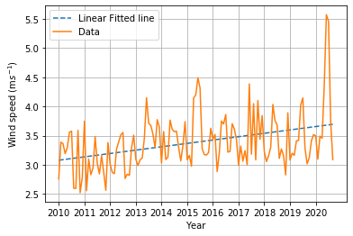

```python
fig,ax = plt.subplots()
f = lambda a,b,x: b+a*x
x=np.arange(len(mon_WND))

ax.plot(x,f(lin.slope,lin.intercept,x),'--',label='Linear Fitted line')
ax.plot(x,mon_WND,label='Data')
ax.grid()
ax.set_xticks(np.arange(0,len(mon_WND),12))
ax.set_xticklabels(np.arange(2010,2021))
ax.set_xlabel('Year')
ax.set_ylabel('Wind speed (m$s^{-1}$)')
ax.legend()
```

There is a weak increasing trend in monthly mean wind speed in Shenzhen for the past 10 years.

# Explore a data set

Dataset: NOAA Integrated Surface Dataset  
https://www.ncdc.noaa.gov/data-access/land-based-station-data/land-based-datasets

Station: Los Angeles Downtown, CA USA  
Variables:  
AA1:Liquid precipitation (mm)  
DEW:Dew point temperature (Celsius degree)  
VIS:Visibility (meters)

```python
# Read .tsv data using pd.read_csv
ds = pd.read_csv('Data/PS2/2749432.csv',)
ds.head()
```

|  | STATION | NAME | LATITUDE | LONGITUDE | ELEVATION | DATE | SOURCE | REPORT_TYPE | CALL_SIGN | QUALITY_CONTROL | AA1 | DEW | KB1 | RH1 | VIS |
| --- | --- | --- | --- | --- | --- | --- | --- | --- | --- | --- | --- | --- | --- | --- | --- |
| 0 | 72287493134 | LOS ANGELES DOWNTOWN USC, CA US | 34.0236 | -118.2911 | 54.6 | 2000-01-01T00:00:00 | 5 | FM-15 | KCQT | V020 | NaN | +0089,5 | NaN | NaN | 016000,5,9,9 |
| 1 | 72287493134 | LOS ANGELES DOWNTOWN USC, CA US | 34.0236 | -118.2911 | 54.6 | 2000-01-01T01:00:00 | 5 | FM-15 | KCQT | V020 | NaN | +0094,5 | NaN | NaN | 016000,5,9,9 |
| 2 | 72287493134 | LOS ANGELES DOWNTOWN USC, CA US | 34.0236 | -118.2911 | 54.6 | 2000-01-01T02:00:00 | 5 | FM-15 | KCQT | V020 | NaN | +0094,5 | NaN | NaN | 016000,5,9,9 |
| 3 | 72287493134 | LOS ANGELES DOWNTOWN USC, CA US | 34.0236 | -118.2911 | 54.6 | 2000-01-01T03:00:00 | 5 | FM-15 | KCQT | V020 | NaN | +0094,5 | NaN | NaN | 016000,5,9,9 |
| 4 | 72287493134 | LOS ANGELES DOWNTOWN USC, CA US | 34.0236 | -118.2911 | 54.6 | 2000-01-01T04:00:00 | 5 | FM-15 | KCQT | V020 | NaN | +0089,5 | NaN | NaN | 014400,5,9,9 |

```python
ds_sel = ds[['DATE','AA1','DEW','VIS']].dropna(axis=0)
ds_sel.head()
```

|  | DATE | AA1 | DEW | VIS |
| --- | --- | --- | --- | --- |
| 8929 | 2001-01-01T09:00:00 | 01,0000,9,5 | +0122,5 | 002400,5,9,9 |
| 8930 | 2001-01-01T10:00:00 | 01,0000,9,5 | +0122,5 | 002800,5,9,9 |
| 8931 | 2001-01-01T11:00:00 | 01,0000,9,5 | +0117,5 | 002800,5,9,9 |
| 8932 | 2001-01-01T12:00:00 | 01,0000,9,5 | +0111,5 | 003200,5,9,9 |
| 8933 | 2001-01-01T13:00:00 | 01,0000,9,5 | +0094,5 | 004800,5,9,9 |

## Convert and index data

```python
DATE=ds_sel.DATE.apply(lambda x:pd.to_datetime(x)).to_frame(name='DATE')
```

```python
LAX=DATE.copy()
```

```python
VAR = ['AA1','DEW','VIS']
fields=['Hours','Depth','QP_1','QP_2','Dew','QD','VIS','QV']
```

```python
#for var in VAR:
for a,b in zip([0,1],[2,3]):
    dfs=ds_sel[VAR[0]].apply(lambda x:int(x.split(',')[a])).to_frame(name=fields[a])
    LAX=pd.merge(LAX,dfs,right_index=True,left_index=True)

    dfs=ds_sel[VAR[0]].apply(lambda x:(x.split(',')[b])).to_frame(name=fields[b])
    LAX=pd.merge(LAX,dfs,right_index=True,left_index=True)

for x,y,z in zip(VAR[1:],[4,6],[5,7]):
    dfs=ds_sel[x].apply(lambda x:int(x.split(',')[0])).to_frame(name=fields[y])
    LAX=pd.merge(LAX,dfs,right_index=True,left_index=True)

    dfs=ds_sel[x].apply(lambda x:(x.split(',')[1])).to_frame(name=fields[z])
    LAX=pd.merge(LAX,dfs,right_index=True,left_index=True)
```

```python
LAX = LAX.set_index(LAX.DATE)
LAX.head()
```

| DATE | DATE | Hours | QP_1 | Depth | QP_2 | Dew | QD | VIS | QV |
| --- | --- | --- | --- | --- | --- | --- | --- | --- | --- |
| 2001-01-01 09:00:00 | 2001-01-01 09:00:00 | 1 | 9 | 0 | 5 | 122 | 5 | 2400 | 5 |
| 2001-01-01 10:00:00 | 2001-01-01 10:00:00 | 1 | 9 | 0 | 5 | 122 | 5 | 2800 | 5 |
| 2001-01-01 11:00:00 | 2001-01-01 11:00:00 | 1 | 9 | 0 | 5 | 117 | 5 | 2800 | 5 |
| 2001-01-01 12:00:00 | 2001-01-01 12:00:00 | 1 | 9 | 0 | 5 | 111 | 5 | 3200 | 5 |
| 2001-01-01 13:00:00 | 2001-01-01 13:00:00 | 1 | 9 | 0 | 5 | 94 | 5 | 4800 | 5 |

## Quality check

QP_2: LIQUID-PRECIPITATION quality code  
1=Passed all quality control checks  
5=Passed all quality control checks, data originate from an NCEI data source

### Filtering Method 1: data passed all quality checks

```python
Depth_pass=LAX.where(LAX.QP_2.isin(['1','5']))
len(Depth_pass)
```

```
197994
```

### Filtering Method 2: drop all missing values

```python
Depth_pass=LAX['Depth'].replace(9999,np.nan).dropna()
len(Depth_pass)
```

```
197992
```

Resample hourly rainfall to daily data

```python
Depth_day=Depth_pass.resample('D').sum()
Depth_day
```

```
DATE
2001-01-01    0.0
2001-01-02    3.0
2001-01-03    0.0
2001-01-04    0.0
2001-01-05    0.0
             ...
2021-10-10    0.0
2021-10-11    0.0
2021-10-12    0.0
2021-10-13    0.0
2021-10-14    0.0
Freq: D, Name: Depth, Length: 7592, dtype: float64
```

## Extreme rainfall (95th percentile)

Define extreme rainfall to be the 95th percentile of wet day precipitation  
Define wet days as daily precipitation larger than 1.0 mm

```python
Depth_wet=Depth_day[Depth_day>1]
```

Group by year

```python
year_group=np.asarray(list(Depth_wet.groupby(Depth_wet.index.year))).T[1]
year_group[0].head()
```

```
DATE
2001-01-02      3.0
2001-01-08     58.0
2001-01-09     11.0
2001-01-10     16.0
2001-01-11    958.0
Name: Depth, dtype: float64
```

```python
extreme_wet_95=pd.DataFrame({
    'Year':np.arange(2001,2022),
    'Extreme_depth':list(map(lambda data:np.percentile(data,95),year_group)),
})
extreme_wet_95=extreme_wet_95.set_index('Year')
```

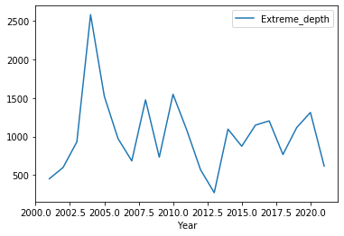

```python
extreme_wet_95.plot()
```

## R95TOT: total amount of rainfall that is greater than 95th percentile rainfall baseline

```python
R95TOT=pd.DataFrame({
    'Year':np.arange(2001,2022),
    'R95TOT':
    list(map(lambda data,base:data[data>float(base)].sum(),year_group,extreme_wet_95.values))
})
R95TOT=R95TOT.set_index('Year')
```

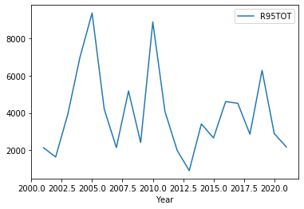

```python
R95TOT.plot()
```

## Extreme rainfall (95th percentile) trend

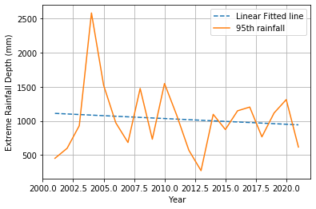

```python
lin = stats.linregress(np.arange(2001,2022),extreme_wet_95['Extreme_depth'].values)

fig,ax = plt.subplots()
f = lambda a,b,x: b+a*x
x=np.arange(2001,2022)

ax.plot(x,f(lin.slope,lin.intercept,x),'--',label='Linear Fitted line')
ax.plot(x,extreme_wet_95['Extreme_depth'],label='95th rainfall')
ax.grid()
ax.set_xlabel('Year')
ax.set_ylabel('Extreme Rainfall Depth (mm)')
ax.legend()
```

## Precipitation climatology mean for 2001-2011

**Select data from 2001-2011**

```python
Depth_sel=Depth_day.where(Depth_day.index.year.isin(np.arange(2001,2012))).dropna()
Depth_sel.head()
```

```
DATE
2001-01-01    0.0
2001-01-02    3.0
2001-01-03    0.0
2001-01-04    0.0
2001-01-05    0.0
Freq: D, Name: Depth, dtype: float64
```

```python
Depth_clim=Depth_sel.groupby(Depth_sel.index.dayofyear).mean()
Depth_clim
```

```
DATE
1       62.636364
2      209.363636
3      232.454545
4       39.727273
5      122.727273
          ...
362      4.818182
363    450.272727
364    290.636364
365     56.909091
366    761.500000
Name: Depth, Length: 366, dtype: float64
```

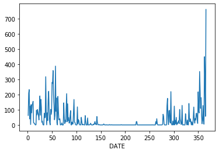

```python
Depth_clim.plot()
```

**Group and reshape data**

```python
year_group=np.asarray(list(Depth_day.groupby(Depth_day.index.year))).T[1]
year_group[0]
```

```
DATE
2001-01-01      0.0
2001-01-02      3.0
2001-01-03      0.0
2001-01-04      0.0
2001-01-05      0.0
              ...
2001-12-27      0.0
2001-12-28      0.0
2001-12-29    101.0
2001-12-30     75.0
2001-12-31     54.0
Freq: D, Name: Depth, Length: 365, dtype: float64
```

## Precipitation anomaly relative to 2001-2011

```python
Depth_anom=pd.concat(
    list(map(
        lambda data:data-Depth_clim.where(Depth_clim.index.isin(data.index.dayofyear)).dropna().values
        ,year_group)
        )
)
Depth_anom
```

```
DATE
2001-01-01    -62.636364
2001-01-02   -206.363636
2001-01-03   -232.454545
2001-01-04    -39.727273
2001-01-05   -122.727273
                 ...
2021-10-10      0.000000
2021-10-11      0.000000
2021-10-12      0.000000
2021-10-13   -126.181818
2021-10-14   -175.272727
Freq: D, Name: Depth, Length: 7592, dtype: float64
```

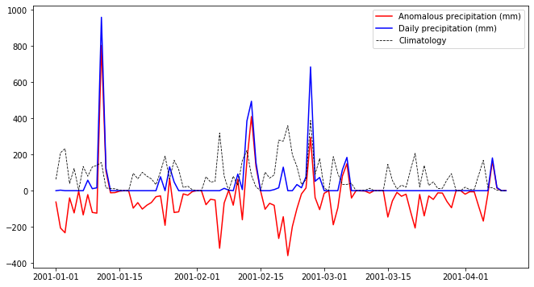

```python
fig,ax=plt.subplots(figsize=(11,6))
ax.plot(Depth_anom[:100],color='r',label='Anomalous precipitation (mm)')
ax.plot(Depth_day[:100],color='b',label='Daily precipitation (mm)')
ax.plot(Depth_anom.index[:100],Depth_clim.values[:100],lw=0.8,linestyle='--',color='k',label='Climatology')
plt.legend()
```